# Aula 07

Pacotes utilizados neste RMD.

```r
library("rmdformats")
library("readxl")
library("dplyr")
```

## Análise de variância - ANOVA

Começa explicando sobre noções de delineamento de experimento: unidade experimental, tratamento, repetição, planejamento de experimento e delineamento totalmente ao acaso.

Tipos de soma do quadrado dos erros:

SQTotal: variação em torno da média global.

SQEntre: variação entre as médias dos tratamentos com a média global.

SQDentro: variação dentro de cada tratamento.

Variação Total = Variação Entre + Variação Dentro

Exemplo: Um experimento deseja avaliar o ganho de peso de peixes

```r
dados <- read_excel("07_Dados.xlsx")
attach(dados)
head(dados)
```

```
## # A tibble: 6 × 2
##   Dieta  Peso
##   <chr> <dbl>
## 1 A      34
## 2 A      34.4
## 3 A      32.9
## 4 A      31.1
## 5 A      32.3
## 6 A      34.4
```

Qual a média global neste caso? Ou seja, independente da dieta que o peixe recebeu.

```r
mean(Peso)
```

```
## [1] 32.16
```

Qual a média entre cada tratamento (dieta)?

```r
tapply(Peso,Dieta,mean)
```

```
##        A        B        C        D
## 32.94000 31.80667 33.73333 30.16000
```

Qual a variância entre cada tratamento?

```r
tapply(Peso,Dieta,var)
```

```
##         A         B         C         D
##  4.599714 14.493524  6.345238  5.771143
```

```r
tapply(Peso,Dieta,sd)
```

```
##        A        B        C        D
## 2.144694 3.807036 2.518976 2.402320
```

Podemos ver a variabilidade de cada tratamento por meio de um boxplot também.

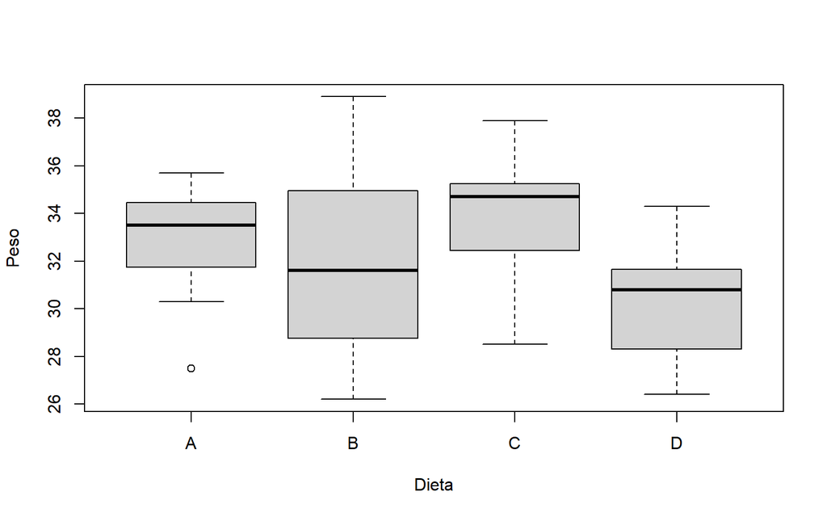

```r
boxplot(Peso~Dieta)
```

Ela cria um modelo linear que utiliza como parâmetros as diferenças das dietas com uma dieta de referência (no caso a dieta A). Seria como cada dieta está afetando no valor do peso (interessante). Veremos melhor sobre isso na próxima aula.

```r
modelo <- lm(Peso~Dieta)
modelo
```

```
##
## Call:
## lm(formula = Peso ~ Dieta)
##
## Coefficients:
## (Intercept)       DietaB       DietaC       DietaD
##     32.9400      -1.1333       0.7933      -2.7800
```

```r
anova <- aov(modelo)
summary(anova)
```

```
##             Df Sum Sq Mean Sq F value  Pr(>F)
## Dieta        3  108.1   36.04   4.619 0.00588 **
## Residuals   56  436.9    7.80
## ---
## Signif. codes:  0 '***' 0.001 '**' 0.01 '*' 0.05 '.' 0.1 ' ' 1
```

Quadro da anova:

Causas da variação: Dieta e Resíduos.

Soma do quadrado dos erros: SQEntre e SQDentre

Quadrado médio: Soma do quadrado dos erros dividido pelo respectivo grau de liberdade.

Estatística F: Razão entre o quadrado médio do tratamento com o quadrado médio do resíduo. Quanto maior, indica que o peso médio são distintos.

$F_{obs} = \frac{QMed_{Entre}}{QMed_{Dentre}} \sim \frac{\chi ^2/gl1}{\chi ^2/gl2}\sim F(gl1,gl2)$

Suposição: normalidade